# Assignment 2

Cheng Zhang cz2532

September 27, 2018

### Background

Analysis dataset of NYChousing.csv

#### part 1: Loading and Cleaning the Data in R

1. Load the data into a dataframe called housing.

```r
# We derectly import a csv file into R, it will automatically be a dataframe.
# We can use class()to check the type of dataset.

setwd("C:/Users/Alan_/Desktop/Semester1 Courses/STAT computing/Week2/Assignment 2")
housing <- read.csv("NYChousing.csv", header = TRUE, as.is = TRUE)
class(housing)
```

```
## [1] "data.frame"
```

2. How many rows and columns does the dataframe have?

```r
dim(housing)
```

```
## [1] 2506   22
```

3. Run this command, and explain, in words, what this does: apply(is.na(housing), 2, sum).

```r
apply(is.na(housing), 2, sum)
```

```
##                            UID                   PropertyName
##                              0                              0
##                            Lon                            Lat
##                             15                             15
##                       AgencyID                           Name
##                              0                              0
##                          Value                        Address
##                             52                              0
##                 Violations2010                     REACNumber
##                              0                           1873
##                        Borough                             CD
##                              0                              0
##            CityCouncilDistrict                    CensusTract
##                             10                              0
##                  BuildingCount                      UnitCount
##                              0                              0
##                      YearBuilt                          Owner
##                              0                              0
##                    Rental.Coop              OwnerProfitStatus
##                              0                              0
##      AffordabilityRestrictions StartAffordabilityRestrictions
##                              0                              5
```

##### This code count the total number of missing values in every column in the dataset ‘housing’ and print every column names and number of missing values related to those columns.

4. Remove the rows of the dataset for which the variable Value is NA.

```r
# is.na() returns boolean mask of each row

housing <- housing[is.na(housing[ , "Value"]) == FALSE, ]
```

22. How many rows did you remove with the previous call? Does this agree with your result from (iii)?

```r
housing <- read.csv("NYChousing.csv", header = TRUE, as.is = TRUE)
with_na <- length(housing[,"Value"])

housing <- housing[is.na(housing["Value"]) == FALSE, ]
without_na <- length(housing[,"Value"])

with_na - without_na
```

```
## [1] 52
```

##### The previous call removes the 52 rows, which agrees with the result in (iii)

6. Create a new variable in the dataset called logValue that is equal to the logarithm of the property’s Value. What are the minimum, median, mean, and maximum values of logValue?

```r
# log() should be apply after extracting the column

housing["logValue"] <- log(housing[,"Value"])
summary(housing["logValue"])
```

```
##     logValue
##  Min.   : 8.41
##  1st Qu.:12.49
##  Median :13.75
##  Mean   :13.68
##  3rd Qu.:14.80
##  Max.   :20.47
```

##### Minimum of logValue: 8.41

##### Median of logValue: 13.75

##### Mean of logValue: 13.68

##### Maximum of logValue: 20.47

7. Create a new variable in the dataset called logUnits that is equal to the logarithm of the number of units in the property. The number of units in each piece of property is stored in the variable UnitCount.

```r
housing["logUnits"] <- log(housing[,"UnitCount"])
```

8. Finally create a new variable in the dataset called after1950 which equals TRUE if the property was built in or after 1950 and FALSE otherwise. You’ll want to use the YearBuilt variable here. This can be done in a single line of code.

```r
housing["after1950"] <- ifelse(housing[,"YearBuilt"] >= 1950, TRUE, FALSE)
```

#### part 2: EDA

The column Borough contains the Borough of each property and is one of either Bronx, Manhattan, Staten Island, Brooklyn, or Queens.

1. Plot property logValue against property logUnits. Name the x and y labels of the plot appropriately. logValue should be on the y-axis.

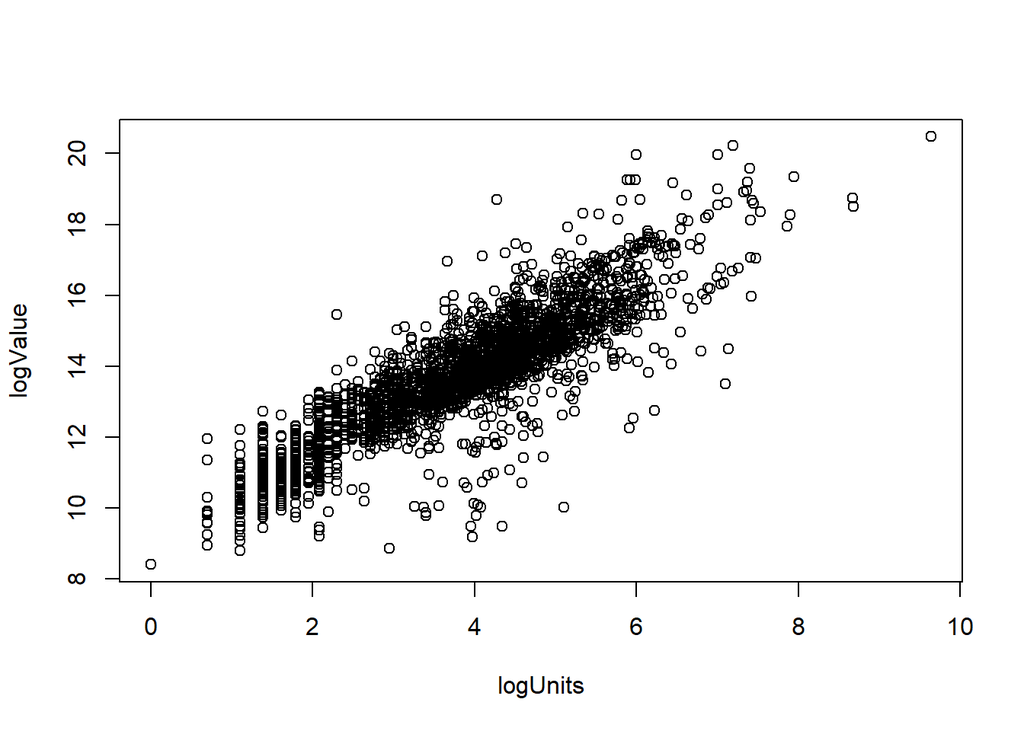

```r
x <- housing[,"logUnits"]
y <- housing[,"logValue"]
plot(x,y, xlab = "logUnits", ylab = "logValue")
```

2. Make the same plot as above, but now include the argument col = factor(housing$after1950). Describe this plot and the covariation between the two variables. What does the coloring in the plot tell us? Hint: legend("bottomright", legend = levels(factor(housing$after1950)), fill = unique(factor(housing$after1950))).

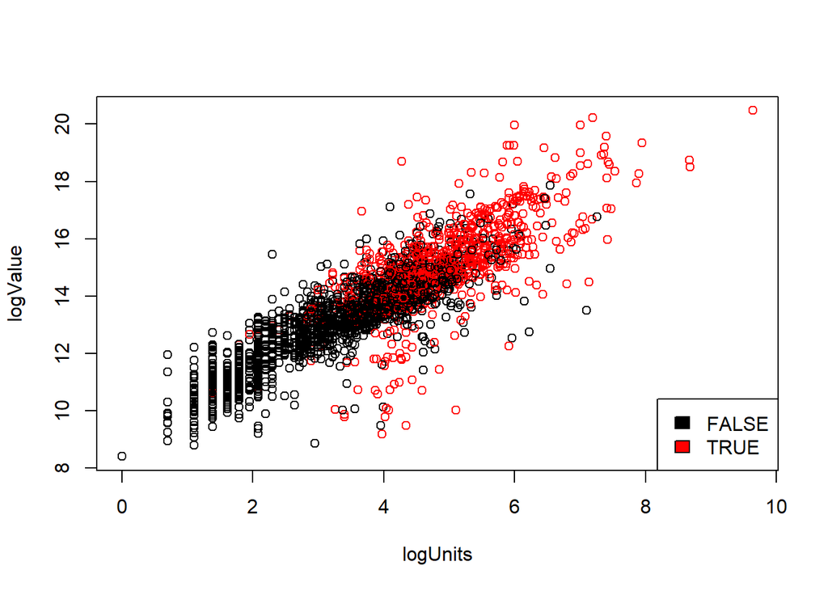

```r
x <- housing[,"logUnits"]
y <- housing[,"logValue"]
plot(x,y, xlab = "logUnits", ylab = "logValue", col = factor(housing$after1950))
legend("bottomright", legend = levels(factor(housing$after1950)), fill = unique(factor(housing$after1950)))
```

3. The cor() function calculates the correlation coecient between two variables. What is the correlation between property logValue and property logUnits in (i) the whole data, (ii) just Manhattan (iii) just Brooklyn (iv) for properties built after 1950 (v) for properties built before 1950?

```r
#(1)
all_cor <- cor(x = housing[,"logValue"], y = housing[,"logUnits"])
all_cor
```

```
## [1] 0.8727348
```

```r
#(2)
Manhattan_cor = cor(x = housing[housing["Borough"] == "Manhattan" , "logValue"], y = housing[housing["Borough"] == "Manhattan" , "logUnits"])
Manhattan_cor
```

```
## [1] 0.8830348
```

```r
#(3)
Brooklyn_cor = cor(x = housing[housing["Borough"] == "Brooklyn" , "logValue"], y = housing[housing["Borough"] == "Brooklyn" , "logUnits"])
Brooklyn_cor
```

```
## [1] 0.9102601
```

```r
#(4)
after1950_cor <- cor(x = housing[housing["after1950"] == TRUE, "logValue"], y = housing[housing["after1950"] == TRUE, "logUnits"])
after1950_cor
```

```
## [1] 0.721735
```

```r
#(5)
before1950_cor <- cor(x = housing[housing["after1950"] == FALSE, "logValue"], y = housing[housing["after1950"] == FALSE, "logUnits"])
before1950_cor
```

```
## [1] 0.8643297
```

Correlations are as follows: (i) the whole data: 0.8727348 (ii) just Manhattan: 0.8830348 (iii) just Brooklyn: 0.9102601 (iv) for properties built after 1950: 0.721735 (v) for properties built before 1950: 0.8643297

4. Make a single plot showing property logValue against property logUnits for Manhat- tan and Brooklyn. When creating this plot, clearly distinguish the two boroughs.

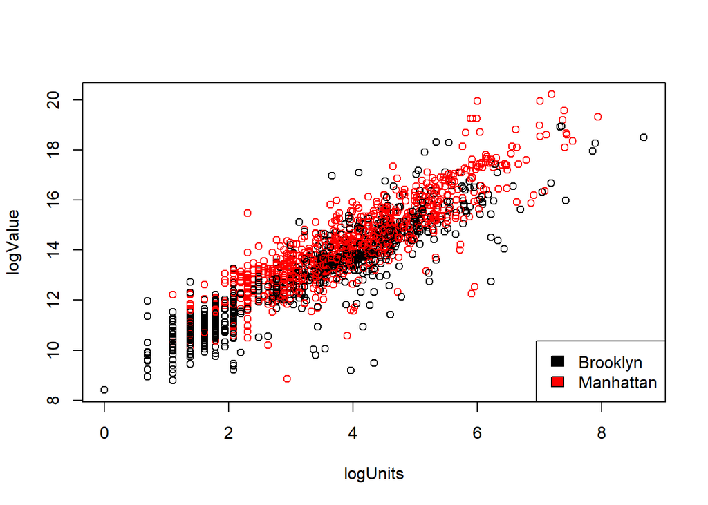

```r
# When the condition contains more than one item, the condition should be given in c()

# We need to use | if there are multiply condition to choose rows.
# housing["Borough"] == c("Manhattan") | housing["Borough"] == c("Brooklyn")
# If we just use c(a,b), it will be regarded as just condition a exists
# y <- housing[housing["Borough"] == c("Manhattan","Borough") ,c("Borough","logUnits","logValue")]


x <- housing[housing["Borough"] == c("Manhattan") | housing["Borough"] == c("Brooklyn") ,c("Borough","logUnits","logValue")]


plot(logValue ~ logUnits, data = x, xlab = "logUnits", ylab = "logValue", col = factor(x[,"Borough"]))

legend("bottomright", legend = levels(factor(housing[housing["Borough"] == c("Manhattan", "Brooklyn"),"Borough"])), fill = unique(factor(housing[housing["Borough"] == c("Manhattan", "Brooklyn"),"Borough"])))
```

22. Consider the following block of code. Give a single line of R code which gives the same final answer as the block of code. There are a few ways to do this.

```r
# given code
# function: get the median value of housing price in Manhattan without stripping the na values

manhat.props <- c()
for (props in 1:nrow(housing)) {
if (housing$Borough[props] == "Manhattan") {
manhat.props <- c(manhat.props, props)
}
}
med.value <- c()
for (props in manhat.props) {
med.value <- c(med.value, housing$Value[props])
}
med.value <- median(med.value, na.rm = TRUE)
med.value
```

```
## [1] 1172362
```

```r
# my code
median_Manhattan <- median(housing[housing["Borough"] == "Manhattan", "Value"], na.rm = TRUE)
median_Manhattan
```

```
## [1] 1172362
```

6. Make side-by-side box plots comparing property logValue across the five boroughs.

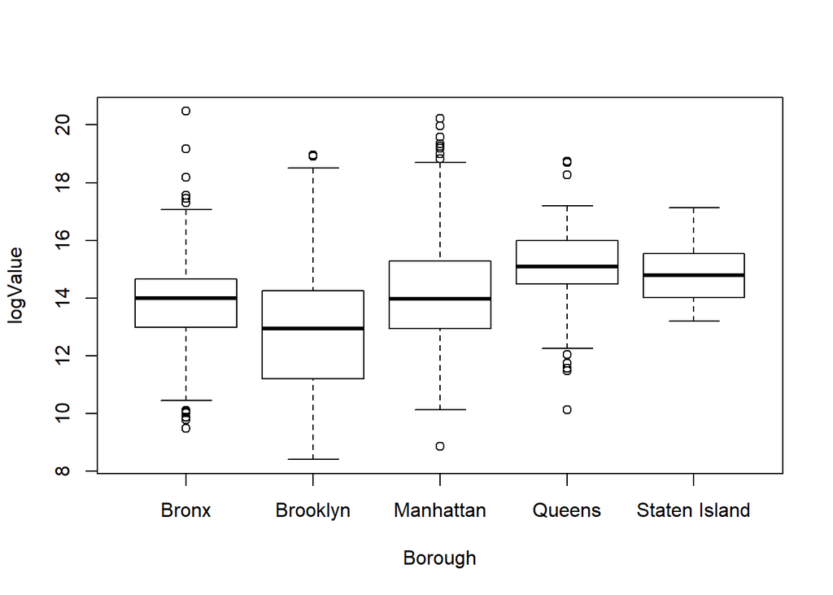

```r
# We can directly put y~x into boxplot() statement rather than generate new data sets

boxplot(housing[,"logValue"]~housing[,"Borough"], xlab = "Borough", ylab = "logValue")
```

7. For five boroughs, what are the median property values? (Use Value here, not logValue.)

```r
# use function on different parts of a vector: tapply(vector, factor, function)

factor_borough <- factor(housing[,"Borough"])
tapply(housing[,"Value"], factor_borough, median)
```

```
##         Bronx      Brooklyn     Manhattan        Queens Staten Island
##       1192950        417610       1172362       3611700       2654100
```

##### The median value of five boroughs are as follows:

##### Bronx: 1192950, Brooklyn: 417610, Manhattan: 1172362, Queens:3611700, Staten Island: 2654100